# What Makes a Great Disc Golfer?

by Daniel Weiss

# Introduction

The world has changed drastically over the past year and a half, but not all of that change has been negative. Disc golf is a sport which has seen tremendous growth recently, in large part due to the restrictions of the pandemic. In case you have been living under a [Roc](https://www.innovadiscs.com/disc/roc/), you can take a look at the Professional Disc Golf Association's (PDGA's) [beginner's guide](https://www.pdga.com/news/what-disc-golf-guide-parents-kids) which explains the basics of the game of disc golf and how it compares to traditional ball golf.

Just like most sports, there are people who dedicate their lives to competing at a professional level in the sport they love, and disc golf is surely not an exception. During the rapid growth of disc golf, the professional disc golf scene has seen increased interest as well. When watching professional disc golfers play people often wonder what sets the top disc golfers apart from other professionals, so that they can try to translate that into their own game.

In this analysis we'll use the data science pipeline to try to figure out what kind of factors are important in making professional disc golfers so good to see what sets the top professionals apart from the rest. The [data science pipeline](https://towardsdatascience.com/a-beginners-guide-to-the-data-science-pipeline-a4904b2d8ad3) is essentially a set of steps that allow us to take raw data sets and answer questions that we may have pertaining to the data. Note that these steps are not strictly sequential, and at any point along the pipeline we can go back to a previous step to help with later steps.

# Preliminary Set Up

Througout our analysis we will be using python code to help us. Before we can begin, we'll import all of the packages that will be used throughout the project. If you would like to look at any of these packages more in depth, you can find the package's documentation online with a quick search (e.g. googling "beautifulsoup documentation" will lead you [here](https://www.crummy.com/software/BeautifulSoup/bs4/doc/)).

```python
# This simply supresses output in Google Colab
%%capture

# Utility
from IPython.display import display, Latex
import time
import re

# Data handling
import numpy as np
import pandas as pd

# Plotting
import matplotlib.pyplot as plt
import seaborn as sns

# Statistics and maching learning
import statsmodels.api as sm
from sklearn.linear_model import LinearRegression

# Web scraping
from bs4 import BeautifulSoup
import requests

# Selenium requires some special setup, so we'll do that separate from the rest

# Install chromium driver and selenium
!apt update
!apt install chromium-chromedriver
!pip install selenium

# Import all of the necessary selenium components
from selenium import webdriver
from selenium.webdriver.support.ui import WebDriverWait
from selenium.webdriver.support.expected_conditions import presence_of_element_located
from selenium.webdriver.common.by import By

# Set the options that we want
options = webdriver.ChromeOptions()
options.add_argument('--headless')
options.add_argument('--no-sandbox')

# Create our driver and set the options
driver = webdriver.Chrome(options=options)
```

# Grabbing the Data

So, let's begin with some data science! In order to be able to apply data science, we will first need to get sample data that we can analyze. There are typically a few ways to get data, ranging from easy methods like finding online datasets on websites such as [Github](https://github.com/awesomedata/awesome-public-datasets) or [Kaggle](https://www.kaggle.com/datasets), to more involved such as web scraping, or even collecting your own data.

Unfortunately, despite the vast growth in disc golf lately, the data collection for disc golf has not stayed up to par. There are not many easily accessible data sets for disc golf that are available online. However, there are still websites that do keep track of data for disc golf, but we'll have to do some extra work to get that data. For this analysis, the data for player statistics will come from [UDisc Live](https://udisclive.com/), while the player ratings will be pulled directly from the [PDGA](https://www.pdga.com/).

Since the data from both of these sites is not already availiable as a public data set, we'll use web scraping to get the data directly from the websites' code. For the PDGA website, we will be able to extract the data directly from the site's HTML. However, getting the data from UDisc will be a bit more complicated. Unfortunately, there are some complications with UDisc since the website renders their webpage through javascript scripts so we will have to use [selenium](https://www.selenium.dev/documentation/en/) since it lets us run the scripts in a web browser before getting the HTML, otherwise we would only be able to see the HTML from before the scripts are run, so we wouldn't see the data that we want.

First we need to use the UDisc Live [season stats page](https://udisclive.com/players?d=MPO&t=stats&z=season) to get a list of all of the players that we want to extract stats for, along with their individual player pages so that we can get as many stats as we can for each player.

```python
# We will use selenium's webdriver to visit the UDisc live
# page so that we can scrape the data
url = 'https://udisclive.com/players?d=MPO&t=stats&z=season'
driver.get(url)

# Wait a second after visiting the page before trying to grab the html
# This ensures the page is able to load properly, otherwise we wouldn't
# get the proper html back
time.sleep(1)

# Store the webpage's html and create a BeautifulSoup object so
# we can more easily parse the html we get back
html = driver.page_source
html = BeautifulSoup(html, 'html.parser')

# The data we want is hidden in a div with id main-content
content = html.find('div', attrs={'id': 'main-content'})

# The players names are in a tags, while the stats are in spans
a_tags = content.find_all('a')

# The first a tag on the page is not actually a player, so get rid of it
del a_tags[-1]

# Use list comprehensions to get player names and links to player pages
players = [x.contents[0] for x in a_tags]
links = ['https://udisclive.com' + x.get('href') for x in a_tags]
```

Now we do the hard part. We look through each player page, and keep track of their stats. If you decide to run the next cell on your own, it will definitely take a few minutes.

```python
# Create a wait driver so we can wait for certain elements to be loaded
wait = WebDriverWait(driver, 10)

# get link to pdga page here instead so it's easier to get player ratings
players_stats = []

# Go through each player page and get the player's stats
for link in links:
  # Open the page in a headless chrome browser
  driver.get(link)

  player_stats = []

  # Use the CSS selectors to wait for the stats to show up, then add them to
  # our player_stats list
  for i in range(2, 18):
    selector = f'#react-root > div > div:nth-child(2) > div:nth-child(3) > div.row.center-xs > div > div:nth-child(2) > div:nth-child({i}) > div > div:nth-child(2) > div > div:nth-child(1)'
    player_stats.append(wait.until(presence_of_element_located((By.CSS_SELECTOR, selector))).text)

  players_stats.append(player_stats)
```

We have the stats and the player names, so all we need now is to scrape the PDGA website's [player search](https://www.pdga.com/players?) to find the ratings for each of our players

```python
# Now we need to get player ratings from the PDGA player search
player_ratings = []

# For each player we will scrape the player search page and find the highest
# rating for each search, since our players are the top professionals, their
# rating will be the highest one
for player in players:
  # Some players have different names listed on Udisc and PDGA, so we
  # need to correct for that before starting the scraping
  if player == 'Ricky Wysocki':
    player = 'Richard Wysocki'
  if player == 'Jake Hebenheimer':
    player = 'Jason Hebenheimer'
  if player == 'GT Hancock':
    player = 'G.T. Hancock'
  if player == 'John Bryan Willis II':
    player = 'John Willis'
  if player == 'Loren J Lewis':
    player = 'Loren Lewis'

  # Split the player's name into first and last name so that we can fill
  # in those fields in the URL
  player = player.split(' ')
  html = requests.get(f'https://www.pdga.com/players?FirstName={player[0]}&LastName={player[1]}')

  # Parse the html, looking for all the html tag corresponding to player ratings
  html = BeautifulSoup(html.text, 'html.parser')
  ratings = html.find_all('td', class_='views-field views-field-Rating-1 views-align-center')
  ratings =  [int(x.contents[0]) for x in ratings if x.contents[0] != '\n']

  # Add the max rating that appeared in the search to our player_ratings list
  player_ratings.append(max(ratings))
```

We currently just have a bunch of different lists, so let's combine them into a multi-dimensional list with a list for each player.

```python
all_players = []
for i in range(0, len(players)):
  # Add the player's rank to the list
  player = [player_ratings[i]]

  # Add the player name to the list
  player.append(players[i])

  # Add each of the stats to the player's list too
  for j in range(0, len(players_stats[0])):
    player.append(players_stats[i][j])

  # Now add the player and their stats to player_stats
  all_players.append(player)
```

Finally, we can store our data in a pandas dataframe.

```python
stat_categories = ['Player Rating', 'Name', 'Driving - Fairway Hits', 'Driving - Off Fairway', 'Driving - Short', 'Driving - Out of Bounds',
                   'Greens in Regulation - Circle 1', 'Greens in Regulation - Circle 2', 'Greens Before Regulation - Circle 1',
                   'Greens Before Regulation - Circle 2', 'Scramble', 'Out of Bounds Rate', 'Bounce Back', 'Parked', 'Putting - Circle 1',
                   'Putting - Circle 1x', 'Putting - Circle 2', 'Throw in']

# Create our dataframe using the data we collected and stat category names
player_stats_df = pd.DataFrame(all_players, columns=stat_categories)
player_stats_df
```

|  | Player Rating | Name | Driving - Fairway Hits | Driving - Off Fairway | Driving - Short | Driving - Out of Bounds | Greens in Regulation - Circle 1 | Greens in Regulation - Circle 2 | Greens Before Regulation - Circle 1 | Greens Before Regulation - Circle 2 | Scramble | Out of Bounds Rate | Bounce Back | Parked | Putting - Circle 1 | Putting - Circle 1x | Putting - Circle 2 | Throw in |
| --- | --- | --- | --- | --- | --- | --- | --- | --- | --- | --- | --- | --- | --- | --- | --- | --- | --- | --- |
| 0 | 1056 | Ricky Wysocki | 78.27% | 7.5% | 7.88% | 6.35% | 56.79% | 75.31% | 3.09% | 3.7% | 66.67% | .086 | 43.33% | 22.02% | 94.03% | 88.84% | 32.43% | 1.85% |
| 1 | 1051 | Paul McBeth | 81.36% | 5.29% | 7.3% | 6.05% | 57.14% | 77.25% | 2.12% | 2.65% | 64.71% | .074 | 57.14% | 21.43% | 90.45% | 81.44% | 38.04% | 0.53% |
| 2 | 1050 | Eagle McMahon | 81.47% | 6.18% | 6.47% | 5.88% | 51.85% | 74.69% | 2.16% | 3.7% | 50.94% | .080 | 29.63% | 15.74% | 92.65% | 87.01% | 38.2% | 0% |
| 3 | 1052 | Calvin Heimburg | 78.19% | 8.15% | 8.37% | 5.29% | 55.09% | 74.54% | 1.62% | 4.17% | 57.97% | .079 | 55.88% | 19.21% | 90.85% | 83.33% | 30.56% | 0.46% |
| 4 | 1046 | Chris Dickerson | 77% | 5.81% | 12.11% | 5.08% | 49.24% | 72.47% | 1.52% | 2.53% | 51.02% | .068 | 43.24% | 16.41% | 90.55% | 81.19% | 27.19% | 0.25% |
| ... | ... | ... | ... | ... | ... | ... | ... | ... | ... | ... | ... | ... | ... | ... | ... | ... | ... | ... |
| 103 | 953 | Daniel Ainsworth | 57.21% | 13.51% | 20.27% | 9.01% | 26.39% | 48.15% | 0.93% | 1.39% | 38.18% | .097 | 31.37% | 7.41% | 85.08% | 67.83% | 5.8% | 0.46% |
| 104 | 989 | Mike Carman | 67.21% | 8.12% | 19.81% | 4.87% | 23.96% | 48.96% | 0% | 0% | 42.31% | .083 | 23.91% | 6.6% | 87.11% | 70.29% | 10.75% | 0.35% |
| 105 | 987 | Christian Olsen | 65.79% | 7.02% | 20.61% | 6.58% | 27.31% | 48.61% | 0% | 0% | 30% | .106 | 16.28% | 7.87% | 84.08% | 62.5% | 13.11% | 0.93% |
| 106 | 959 | Mark McAlister | 54.22% | 16.44% | 24% | 5.33% | 19.91% | 37.04% | 0% | 0.93% | 44.83% | .074 | 15.52% | 2.78% | 83.4% | 68.89% | 7.81% | 0% |
| 107 | 944 | Scott Turner | 54.97% | 9.42% | 26.7% | 8.9% | 18.33% | 33.89% | 0% | 1.11% | 12.77% | .133 | 15.79% | 6.11% | 80.56% | 52.81% | 10.87% | 0.56% |

108 rows × 18 columns

Voila, we now have the ratings and some stats for 108 professional disc golfers, including some of the best in the entire game. We were able to get many different statistical categories on UDisc, each pertaining to important parts of the game. Let's make sure we understand what these stats actually mean before we move on (note that all of our stats except player rating and out of bounds rate are a percentage). Circle 1 is within 10 meters of the basket, and circle 2 is within 20 meters of the basket.

- Player rating $\rightarrow$ A number assigned to a player for their performance in official rounds. Better rounds = higher rating.
- Driving - fairway hits $\rightarrow$ The percentage of drives that land on the fairway.
- Driving - off fairway $\rightarrow$ The percentage of drives that don't land on the fairway
- Driving - short $\rightarrow$ Drives landing outside of circle 2 on a par 3
- Driving - out of bounds $\rightarrow$ Drives that land out of bounds.
- Greens in regulation - circle 1 $\rightarrow$ Throwing a shot into circle 1 (within 10 meters of the basket) with two more strokes until par.
- Greens in regulation - circle 2 $\rightarrow$ Throwing a shot into circle 2 (within 20 meters) with two strokes until par.
- Greens before regulation - circle 1 $\rightarrow$ Throwing a shot into circle 1 with more than two strokes until par.
- Greens before regulation - circle 2 $\rightarrow$ Throwing a shot into circle 2 with more than two strokes until par.
- Scramble $\rightarrow$ Throwing out of bounds or off the fairway and still getting a par or better on the hole.
- Out of bounds rate $\rightarrow$ Rate of throwing out of bounds.
- Bounce back $\rightarrow$ Scoring under par on a hole right after scoring over par on the previous hole.
- Parked $\rightarrow$ Landing 0 to 3.3 meters from the basket.
- Putting - circle 1 $\rightarrow$ Putts made from 0 to 10 meters to the basket.
- Putting - circle 1x $\rightarrow$ Putts made from 3.3 to 10 meters to the basket.
- Putting - circle 2 $\rightarrow$ Putts made from 10 to 20 meters to the basket.
- Throw in $\rightarrow$ Throw made from outside circle 2.

For more information about the player ratings look [here](https://www.pdga.com/ratings), and to learn more about some of the disc golf stats that weren't explained, look [here](https://udisclive.com/about).

# Cleaning the Data

A common saying in data science is "garbage in, garbage out". This refers to the data that is used in analyses. If bad data is used, then your analysis will likely end up bad too. Our data is already pretty clean, so this step will be relatively simple. We aren't missing any data so we don't need to worry about dealing with missing values, so all we need to do is some simple data conversions to make the data easier to work with later on.

```python
# Let's create a deep copy of our dataframe so we still have the original
# if we need it later
clean_player_stats = player_stats_df.copy(deep=True)

# Loop through each row in our dataframe and update the statistical categories
# using regex to get rid of the % sign
for index, row in clean_player_stats.iterrows():
  for i in range(2, len(stat_categories)):
    clean_player_stats.at[index, stat_categories[i]] = re.sub('%', '', row[stat_categories[i]])


# We need to convert the dtype fo each of these columns to int64 from object
# in order for our data to be interpereted properly by pandas
for i in range(2, len(stat_categories)):
  clean_player_stats[stat_categories[i]] = pd.to_numeric(clean_player_stats[stat_categories[i]])

clean_player_stats
```

[output not shown]

|  | Player Rating | Name | Driving - Fairway Hits | Driving - Off Fairway | Driving - Short | Driving - Out of Bounds | Greens in Regulation - Circle 1 | Greens in Regulation - Circle 2 | Greens Before Regulation - Circle 1 | Greens Before Regulation - Circle 2 | Scramble | Out of Bounds Rate | Bounce Back | Parked | Putting - Circle 1 | Putting - Circle 1x | Putting - Circle 2 | Throw in |
| --- | --- | --- | --- | --- | --- | --- | --- | --- | --- | --- | --- | --- | --- | --- | --- | --- | --- | --- |
| 0 | 1056 | Ricky Wysocki | 78.27 | 7.50 | 7.88 | 6.35 | 56.79 | 75.31 | 3.09 | 3.70 | 66.67 | 0.086 | 43.33 | 22.02 | 94.03 | 88.84 | 32.43 | 1.85 |
| 1 | 1051 | Paul McBeth | 81.36 | 5.29 | 7.30 | 6.05 | 57.14 | 77.25 | 2.12 | 2.65 | 64.71 | 0.074 | 57.14 | 21.43 | 90.45 | 81.44 | 38.04 | 0.53 |
| 2 | 1050 | Eagle McMahon | 81.47 | 6.18 | 6.47 | 5.88 | 51.85 | 74.69 | 2.16 | 3.70 | 50.94 | 0.080 | 29.63 | 15.74 | 92.65 | 87.01 | 38.20 | 0.00 |
| 3 | 1052 | Calvin Heimburg | 78.19 | 8.15 | 8.37 | 5.29 | 55.09 | 74.54 | 1.62 | 4.17 | 57.97 | 0.079 | 55.88 | 19.21 | 90.85 | 83.33 | 30.56 | 0.46 |
| 4 | 1046 | Chris Dickerson | 77.00 | 5.81 | 12.11 | 5.08 | 49.24 | 72.47 | 1.52 | 2.53 | 51.02 | 0.068 | 43.24 | 16.41 | 90.55 | 81.19 | 27.19 | 0.25 |
| ... | ... | ... | ... | ... | ... | ... | ... | ... | ... | ... | ... | ... | ... | ... | ... | ... | ... | ... |
| 103 | 953 | Daniel Ainsworth | 57.21 | 13.51 | 20.27 | 9.01 | 26.39 | 48.15 | 0.93 | 1.39 | 38.18 | 0.097 | 31.37 | 7.41 | 85.08 | 67.83 | 5.80 | 0.46 |
| 104 | 989 | Mike Carman | 67.21 | 8.12 | 19.81 | 4.87 | 23.96 | 48.96 | 0.00 | 0.00 | 42.31 | 0.083 | 23.91 | 6.60 | 87.11 | 70.29 | 10.75 | 0.35 |
| 105 | 987 | Christian Olsen | 65.79 | 7.02 | 20.61 | 6.58 | 27.31 | 48.61 | 0.00 | 0.00 | 30.00 | 0.106 | 16.28 | 7.87 | 84.08 | 62.50 | 13.11 | 0.93 |
| 106 | 959 | Mark McAlister | 54.22 | 16.44 | 24.00 | 5.33 | 19.91 | 37.04 | 0.00 | 0.93 | 44.83 | 0.074 | 15.52 | 2.78 | 83.40 | 68.89 | 7.81 | 0.00 |
| 107 | 944 | Scott Turner | 54.97 | 9.42 | 26.70 | 8.90 | 18.33 | 33.89 | 0.00 | 1.11 | 12.77 | 0.133 | 15.79 | 6.11 | 80.56 | 52.81 | 10.87 | 0.56 |

108 rows × 18 columns

Now that our dataframe is looking good, let's discuss how it can help us to answer our question. To quantify how 'good' a professional disc golfer is, we look at the player rating. Then we can use the rest of the statistics to help us determine how each contribute to a player's rating.

# Exploratory Data Analysis

So now that we have our data clean and ready, let's see if we can use some data visualization techniques to help explore the data and see if we can get some insights into potential relationships within the dataset. We can start with a heatmap of our columns to see if there is any correlation between a player's rating and the player's stats.

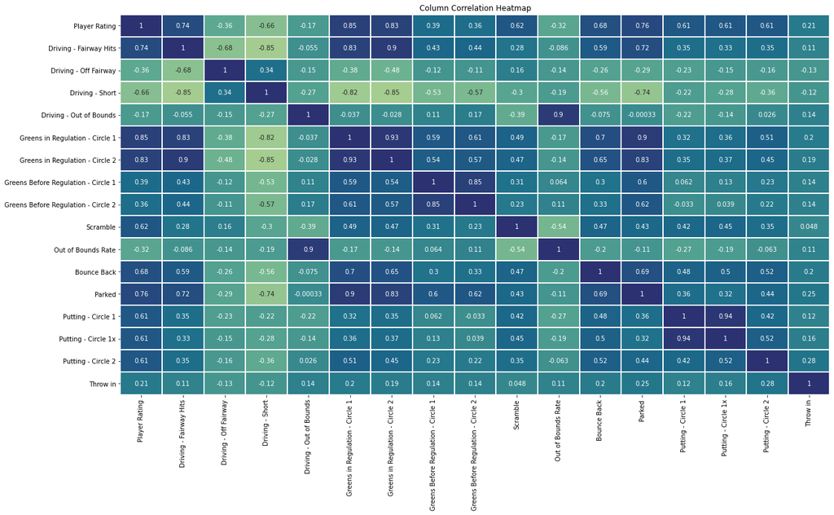

```python
# Let's make a heatmap of the dataframe, but we don't need the Name column
heatmap_data = clean_player_stats.drop(columns=['Name'])

# Create the heatmap from our heatmap_data
fig, ax = plt.subplots(figsize=(20,11))
sns.heatmap(heatmap_data.corr(), annot=True, cmap='crest', linewidths=1, cbar=False)

# Set the title and axes
ax.set_title('Column Correlation Heatmap');
ax.set_xticklabels(labels=ax.get_xticklabels(), rotation=90)
ax.set_yticklabels(labels=ax.get_yticklabels(), rotation=0);
```

As we can see from the top row of the heatmap, player stats range from low to high correlation with the player ratings. As we may expect, the stats correspoinding to throwing off the fairway, driving short, driving out of bounds, and out of bounds rate are the only columns which have a negative correlation with player rating. Maybe next we can explore what the actual correlations look like with a regression line to help us better see the relationships.

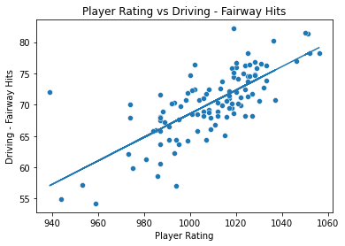

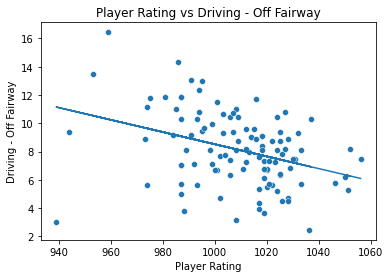

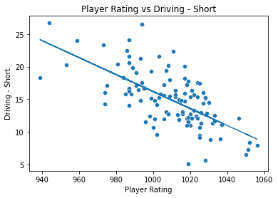

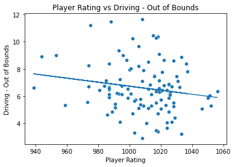

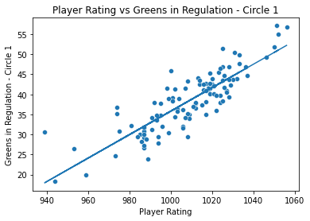

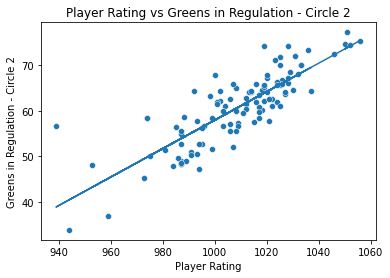

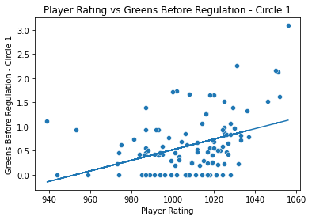

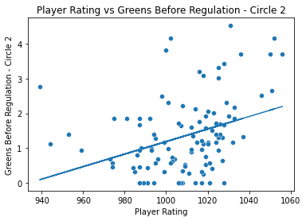

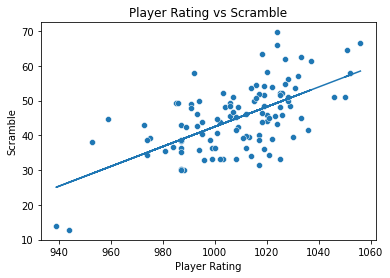

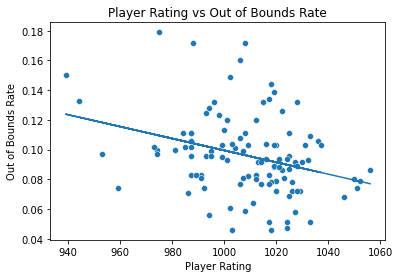

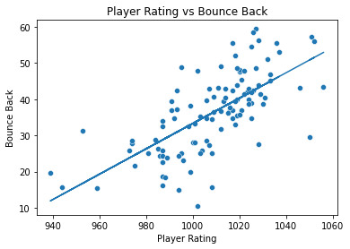

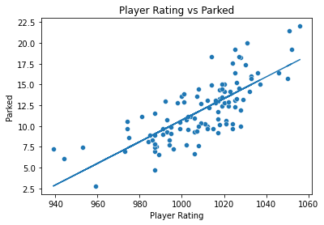

[4 more figures not shown]

```python
# Define a list of the statistic columns that we want to plot, which are all the
# columns except player rating (which will be the y variable), and name
player_stats = stat_categories[2:]

# Plot a scatterplot of Rank vs stats[i] for each of the column names in stats
for i in range(0, len(player_stats)):
  fig, ax = plt.subplots()
  sns.scatterplot(x='Player Rating', y=player_stats[i], data=clean_player_stats)
  ax.set_title(f'Player Rating vs {player_stats[i]}')

  # Save the x and y data in variables for our linear regression
  x = clean_player_stats['Player Rating']
  y = clean_player_stats[player_stats[i]]

  # Let's add a linear regression line to help us visualize a potential relationship
  reg_line = np.polyfit(x=x, y=y, deg=1)
  m, b = np.poly1d(reg_line)
  plt.plot(x, m * x + b)
```

As we can see, some of the player stats like fairway hits and parked seem to have linear regression lines that fit the data pretty well, while others like driving out of bounds and throw in are a little bit more questionable. Next we need to determine if any of these relationships are actually significant.

# Hypothesis Testing

Now we know what our data looks like, and we have some understanding of what correlations exist between our variables. So now we can just throw some machine learning at it and call it a day, right? Well, not quite. In order for any further analysis to be meaningful, we need to determine how we determine the significance of our results. This is where hypothesis testing comes in.

Hypothesis testing is a statistical method that allows us to evaluate different theories (hypotheses) about a population to determine which is best supported by the data that we collected. To perform the hypothesis testing, we will use the steps outlined [here](https://towardsdatascience.com/hypothesis-testing-explained-as-simply-as-possible-6e0a256293cf#b6fc).

First we need to state our hypotheses, which typically consist of a null hypothesis ($H_{0}$), and an altenative hypothesis ($H_{a}$). For our hypothesis testing, we will use the following hypotheses:

$ H_{0} \rightarrow$ There is no significant relationship between player rating and our player stats.

$H_{a} \rightarrow$ There is a significant relationship between player rating and our player stats.

Next we need to decide what our significance level will be. When choosing the significance level, we need to take into account consequences of each of the two types of errors (read about the two types of errors [here](https://towardsdatascience.com/hypothesis-testing-the-what-why-and-how-867d382b99ca). In our case, the implications of type 1 and 2 errors are approximately equivalent, as neither error will result in major consequences. Since we don't need to prefer one error type over another, I will us $\alpha$ = 0.11 as suggested by [this article](https://mpra.ub.uni-muenchen.de/66373/1/MPRA_paper_66373.pdf) for a sample size of 100.

In order to continue with the rest of the steps of hypothesis testing, we will need to calculate the p-values. To do that, we will need to use the statsmodel package, which will perform all of the statistical calculations that we need.

```python
# Put the independent variables in X, and the dependent variables in y
X = clean_player_stats[player_stats]
y = clean_player_stats['Player Rating']

# Fit the ordinary least squares linear regression model to the dataset
model = sm.OLS(y, X).fit()

# Display the statistics from the model
model.summary()
```

OLS Regression Results

| Dep. Variable: | Player Rating | R-squared (uncentered): | 1.000 |
| --- | --- | --- | --- |
| Model: | OLS | Adj. R-squared (uncentered): | 1.000 |
| Method: | Least Squares | F-statistic: | 1.269e+05 |
| Date: | Sat, 15 May 2021 | Prob (F-statistic): | 2.37e-192 |
| Time: | 03:58:02 | Log-Likelihood: | -360.11 |
| No. Observations: | 108 | AIC: | 752.2 |
| Df Residuals: | 92 | BIC: | 795.1 |
| Df Model: | 16 |  |  |
| Covariance Type: | nonrobust |  |  |

|  | coef | std err | t | P>\|t\| | [0.025 | 0.975] |
| --- | --- | --- | --- | --- | --- | --- |
| Driving - Fairway Hits | 7.7348 | 0.620 | 12.481 | 0.000 | 6.504 | 8.966 |
| Driving - Off Fairway | 7.3518 | 0.489 | 15.028 | 0.000 | 6.380 | 8.323 |
| Driving - Short | 7.5825 | 0.583 | 13.008 | 0.000 | 6.425 | 8.740 |
| Driving - Out of Bounds | 8.6774 | 1.137 | 7.633 | 0.000 | 6.420 | 10.935 |
| Greens in Regulation - Circle 1 | 1.4583 | 0.421 | 3.465 | 0.001 | 0.623 | 2.294 |
| Greens in Regulation - Circle 2 | 0.4750 | 0.344 | 1.380 | 0.171 | -0.209 | 1.158 |
| Greens Before Regulation - Circle 1 | -1.4889 | 2.467 | -0.604 | 0.548 | -6.388 | 3.410 |
| Greens Before Regulation - Circle 2 | -1.7402 | 1.423 | -1.223 | 0.224 | -4.565 | 1.085 |
| Scramble | 0.3310 | 0.123 | 2.688 | 0.009 | 0.086 | 0.576 |
| Out of Bounds Rate | -109.8800 | 77.498 | -1.418 | 0.160 | -263.797 | 44.037 |
| Bounce Back | -0.1623 | 0.106 | -1.536 | 0.128 | -0.372 | 0.048 |
| Parked | 0.1637 | 0.637 | 0.257 | 0.798 | -1.101 | 1.429 |
| Putting - Circle 1 | 1.6746 | 0.868 | 1.930 | 0.057 | -0.049 | 3.398 |
| Putting - Circle 1x | -0.0601 | 0.391 | -0.154 | 0.878 | -0.837 | 0.717 |
| Putting - Circle 2 | 0.4446 | 0.143 | 3.118 | 0.002 | 0.161 | 0.728 |
| Throw in | 1.2096 | 1.814 | 0.667 | 0.507 | -2.394 | 4.813 |

| Omnibus: | 20.360 | Durbin-Watson: | 2.059 |
| --- | --- | --- | --- |
| Prob(Omnibus): | 0.000 | Jarque-Bera (JB): | 31.153 |
| Skew: | -0.869 | Prob(JB): | 1.72e-07 |
| Kurtosis: | 4.976 | Cond. No. | 1.83e+04 |

Warnings:  
[1] Standard Errors assume that the covariance matrix of the errors is correctly specified.  
[2] The condition number is large, 1.83e+04. This might indicate that there are  
strong multicollinearity or other numerical problems.

As we can see from the p-values (the P>|t| column), there are actually eight different player stats that have a p-value that is greater than our established significance level. Therefore we should *not* reject $H_{0}$. So what do we do now? Remember that the data science pipeline is not a one way street, so let's go back and test new hypotheses with the same $\alpha$, but with new player stats that don't include the eight with high p-values:

$ H_{0} \rightarrow$ There is no significant relationship between player rating and our new player stats.

$H_{a} \rightarrow$ There is a significant relationship between player rating and our new player stats.

```python
# Put the independent variables in X (dropping the eight stats that didn't have a
# significant enough correlation with player rating), and the dependent variables in y
X = clean_player_stats[['Driving - Fairway Hits', 'Driving - Off Fairway', 'Driving - Short',
                        'Driving - Out of Bounds', 'Greens in Regulation - Circle 1',
                        'Scramble', 'Putting - Circle 1', 'Putting - Circle 2']]
y = clean_player_stats['Player Rating']

# Fit the ordinary least squares linear regression model to the dataset
model = sm.OLS(y, X).fit()

# Display the statistics from the model
model.summary()
```

OLS Regression Results

| Dep. Variable: | Player Rating | R-squared (uncentered): | 1.000 |
| --- | --- | --- | --- |
| Model: | OLS | Adj. R-squared (uncentered): | 1.000 |
| Method: | Least Squares | F-statistic: | 2.387e+05 |
| Date: | Sat, 15 May 2021 | Prob (F-statistic): | 2.09e-210 |
| Time: | 04:00:55 | Log-Likelihood: | -367.92 |
| No. Observations: | 108 | AIC: | 751.8 |
| Df Residuals: | 100 | BIC: | 773.3 |
| Df Model: | 8 |  |  |
| Covariance Type: | nonrobust |  |  |

|  | coef | std err | t | P>\|t\| | [0.025 | 0.975] |
| --- | --- | --- | --- | --- | --- | --- |
| Driving - Fairway Hits | 7.9636 | 0.286 | 27.803 | 0.000 | 7.395 | 8.532 |
| Driving - Off Fairway | 7.1568 | 0.355 | 20.146 | 0.000 | 6.452 | 7.862 |
| Driving - Short | 7.7334 | 0.303 | 25.503 | 0.000 | 7.132 | 8.335 |
| Driving - Out of Bounds | 7.3078 | 0.453 | 16.146 | 0.000 | 6.410 | 8.206 |
| Greens in Regulation - Circle 1 | 1.5421 | 0.233 | 6.617 | 0.000 | 1.080 | 2.004 |
| Scramble | 0.4033 | 0.110 | 3.658 | 0.000 | 0.185 | 0.622 |
| Putting - Circle 1 | 1.5994 | 0.261 | 6.126 | 0.000 | 1.081 | 2.117 |
| Putting - Circle 2 | 0.4221 | 0.135 | 3.135 | 0.002 | 0.155 | 0.689 |

| Omnibus: | 27.708 | Durbin-Watson: | 1.967 |
| --- | --- | --- | --- |
| Prob(Omnibus): | 0.000 | Jarque-Bera (JB): | 70.040 |
| Skew: | -0.918 | Prob(JB): | 6.18e-16 |
| Kurtosis: | 6.492 | Cond. No. | 88.9 |

Warnings:  
[1] Standard Errors assume that the covariance matrix of the errors is correctly specified.

Now that our p-values are within our significance level, we can reject $H_{0}$ and continue on to try to model the relationships that we can now pretty confidently say exist.

# Machine Learning

[Linear regression](https://en.wikipedia.org/wiki/Linear_regression#:~:text=In%20statistics%2C%20linear%20regression%20is,as%20dependent%20and%20independent%20variables). is a commonly used predictive model, which determines the impact each of the independent variables (called predictors) has on the dependent variable, in order to calculate a prediction. It uses a simple line equation which you may be familiar with:

$y = \beta_{0} + \beta_{1}x_{1} + \beta_{2}x_{2} + ... + \beta_{n}x_{n} $

Here y represents the dependent variable, $\beta_{i}$'s represent slopes, and the $x_{i}$'s are the independent variable.

```python
# Fit a linear regression model to our data
lin_reg = LinearRegression(fit_intercept=False).fit(X, y)

# Grab the coeffiecients from the model
slope = lin_reg.coef_.tolist()
intercept = lin_reg.intercept_

# Create a string to show the line equation generated from the model
i = 0
model_eqn = f'$y = {round(intercept, 3)} + '
while i < len(slope) - 1:
  model_eqn += f'{round(slope[i], 3)}x_{i + 1} + '
  i += 1

# Display our equation
display(Latex(model_eqn + f'{round(slope[i], 3)}x_{i + 1}$'))
```

$y = 0.0 + 7.964x_1 + 7.157x_2 + 7.733x_3 + 7.308x_4 + 1.542x_5 + 0.403x_6 + 1.599x_7 + 0.422x_8$

What does the equation of our linear regression line mean? Notice that we made sure to not fit a y-intercept for our model. For our data, a fitting a y-intercept would not make let us get as much information from our model, since we want to see which stats contribute to a higher rating. Let's break it down:

- 0 is the y-intercept
- $x_{1}$ corresponds to our driving fairway hits, and is multiplied by the coefficient 7.964 when trying to predict player rating
- Similarly, $x_{2}$'s (driving off fairway) coefficient is 7.157, and $x_{3}$'s (driving short) is 7.733, etc.

Now some intutition from looking at the equation. The y-intertercept suggests that the base rating of a professional disc golfer if they had 0 in all of our player stats would be 0. In our data set, the top professionals have ratings in the 1050s, so in order for our model to predict their ratings, it puts lots of emphasis on the player stats that we found to be significant in our hypothesis testing. For reference, [here's](https://imgur.com/a/dUM11Dt) a chart created by a redditor back in February of the distribution of PDGA player ratings. We also see that $x_{1}$ has the highest coefficient, which suggests that according to the model, driving fairway hits is the biggest contributor to player rating, with the other driving stats coming close behind. The variable with the highest coefficients after the driving stats are circle 1 greens in regulation and putting in circle 1.

Out of curiosity of how well our model can predict player ratings, let's plot the predictions with residuals. [Residuals](https://www.statisticshowto.com/residual/) are just the difference between a predicted value and the actual value.

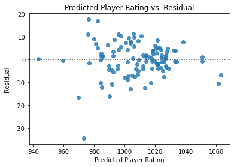

```python
# Create a list of predictions for each player
predictions = lin_reg.predict(X)

# Make a residual plot fo predicted rating and residuals
fig, ax = plt.subplots()
sns.residplot(x=predictions, y=residuals)

# Set title and labels
ax.set_title('Predicted Player Rating vs. Residual')
ax.set_xlabel('Predicted Player Rating')
ax.set_ylabel('Residual');
```

# So, what did we learn?

Through our use of the data science pipeline we were able to analyze the impact that various player stats have on the PDGA rating of a professional disc golfer. Through hypothesis testing we found out that there is a significant relationship between player rating and the following stats: fairway hits, driving off fairway, driving short, driving out of bounds, circle 1 greens in regulation, scrambling, putting in circle 1, and putting in circle 2.

We also fit a multiple linear regression model to our data set, so that we could see what stats our model would put the highest value in. So, if you want to improve your PDGA rating, it may be helpful to work on your driving and circle 1 putts! We could also use our model to predict the rating of others players if we have their stats as well. It is important to note however that the model will likely not be all that accurate for predicting the ratings of amatuer disc golfers, due to the fact that it was only trained on professionals.

I appreciate everyone who takes the time to read through my data science analysis of disc golf. Disc golf has become an amazing hobby (addiction?) of mine over the past 15 months, so I had a blast applying my data science knowledge to learn more about the sport I enjoy so much, and I hope that you leaned a lot from my analysis as well.

# Bonus just for fun...

While I was working on this project I was very curious about what the machine learning algorithm would predict for my player rating. I know that it likely won't be accurate for me as an amatuer since the model was trained on the professionals. However, last time I went disc golfing with a friend, we both kept our stats just to see what the model would think of us.

```python
# Create arrays with stats for a friend and me
Daniel = np.array([[35, 35, 28, 2, 9, 35, 87, 7]])
Friend = np.array([[37, 37, 25, 1, 23, 32, 81, 1]])

# Predict our ratings and print them
print(f'Daniel\'s rating: {int(lin_reg.predict(Daniel)[0])}')
print(f'Friend\'s rating: {int(lin_reg.predict(Friend)[0])}')
```

```
Daniel's rating: 930
Friend's rating: 938
```

Both of these rating predictions are about 30 rating points above what our actual ratings would be right now, but not too bad!